# Cflo-healthy-controls (TC7)

Biplabendu Das

08 March, 2022

## Overview/Goals

Using time-course RNASeq data from healthy Cflo forager heads:

- build a circadian gene co-expression network (GCN),
- annotate the network using published data,

## Step 1: Build circadian GCN

### 1.1 Load data

Dataset: Healthy (uninfected, uninjected) Cflo forager ant heads (three pooled per time point for RNA-extraction and -sequencing), collected every 2h, over a 24h-period. [Control]

```r
# Specify the path to TC5 repo
path_to_tc5_repo = "/Users/biplabendudas/Documents/GitHub/Das_et_al_2021"
# Load the TC5 database
tc5.db <- dbConnect(RSQLite::SQLite(), paste0(path_to_tc5_repo,"/data/TC5_data.db"))

# loading database which contains gene X sample expression data
data.db <- dbConnect(RSQLite::SQLite(), paste0(path_to_repo,"/data/databases/TC7_data.db"))

# specify sample name
sample.name <- c("cflo_control","cflo_ophio-infected","cflo_beau-infected")

# extract the (gene-expr X time-point-of-sampling) data
dat <-
  data.db %>%
  tbl(., paste0(sample.name[1] ,"_fpkm")) %>%
  select(gene_name, everything()) %>%
  collect()

writeLines("What is the dimensions of the original dataset? [Rows = #genes, Cols = #samples]")
```

```
## What is the dimensions of the original dataset? [Rows = #genes, Cols = #samples]
```

```r
dim(dat[-1])
```

```
## [1] 13808    12
```

```r
## Specify a col.scheme
col.scheme <- c("black","#AD212F","#5A829F", "#736D51", "#005C53")
names(col.scheme) <- c("control", "ophio-inf", "beau-inf", "control-brains", "control-brains-nur")
```

### 1.2 Clean data

The above dataset contains all genes (n=13,808) in the ant genome. However, not all of these genes are expressed in the ant head, and some are expressed at very low levels that are not biologically meaningful. Therefore, we will only keep the genes that are “expressed” (≥1 FPKM for at least half of all time points) in the ant head.

```r
# Which genes are expressed throughout the day in forager heads?
  # count the number of time points that has ≥ 1 FPKM
  n.expressed <- apply(dat[-1], 1, function(x) sum(x >= 1))
  # subset the data and only keep the filtered genes
  dat <- dat[which(n.expressed >=6),]

writeLines("Dimensions of the data post-filtering step [Rows = #genes, Cols = #samples]")
```

```
## Dimensions of the data post-filtering step [Rows = #genes, Cols = #samples]
```

```r
dim(dat)
```

```
## [1] 9591   13
```

```r
# save the number of genes and samples
# that will be used to create the circadian GCN
nGenes = nrow(dat)
nSamples = ncol(dat[-1])

## Filter this data to keep only genes from specific modules
which.modules <- c("C21","C22")

# module identity for Cflo-control gene
## specify the location of the csv that has this info.
file_loc <- "/results/WGCNA/cflo/cflo_heads_control_module_identity_new_labels.csv"
## load it into R
mod.identity.all <- read.csv(paste0(path_to_repo,file_loc), stringsAsFactors = F) %>% as_tibble()

## filter to keep only the genes that we are working with
mod.identity <-
  mod.identity.all %>%
  filter(module_identity %in% which.modules) %>%
  select(gene_name,
         module_identity) %>%
  # !!this step is necessary!! #
  arrange(module_identity)


dat <-
  dat %>%
  filter(gene_name %in% mod.identity[["gene_name"]])
```

This is our cleaned, input data file for building the circadian GCN.

### 1.3 Format data

- Log2 transform the data

```r
datExpr = as.data.frame(t(log2(dat[-c(1)]+1)))
names(datExpr) = dat$gene_name
rownames(datExpr) = names(dat)[-c(1)]

# USE THE FOLLOWING CODE TO CHECK IF YOU HAVE ANY BAD SAMPLES #
  # gsg = goodSamplesGenes(datExpr, verbose = 3);
  # gsg$allOK

  # sampleTree = hclust(dist(datExpr0), method = "average");
  # # Plot the sample tree: Open a graphic output window of size 12 by 9 inches
  # # The user should change the dimensions if the window is too large or too small.
  # sizeGrWindow(12,9)
  # #pdf(file = "Plots/sampleClustering.pdf", width = 12, height = 9);
  # par(cex = 1);
  # par(mar = c(0,4,2,0))
  # plot(sampleTree, main = "Sample clustering to detect outliers", sub="", xlab="", cex.lab = 1.5,
  #      cex.axis = 1.5, cex.main = 2)



# visualize the log-transformed data
x = reshape2::melt(as.matrix(t(datExpr)))
colnames(x) = c('gene_id', 'sample', 'value')

writeLines("Visualizing the log-transformed data")
```

```
## Visualizing the log-transformed data
```

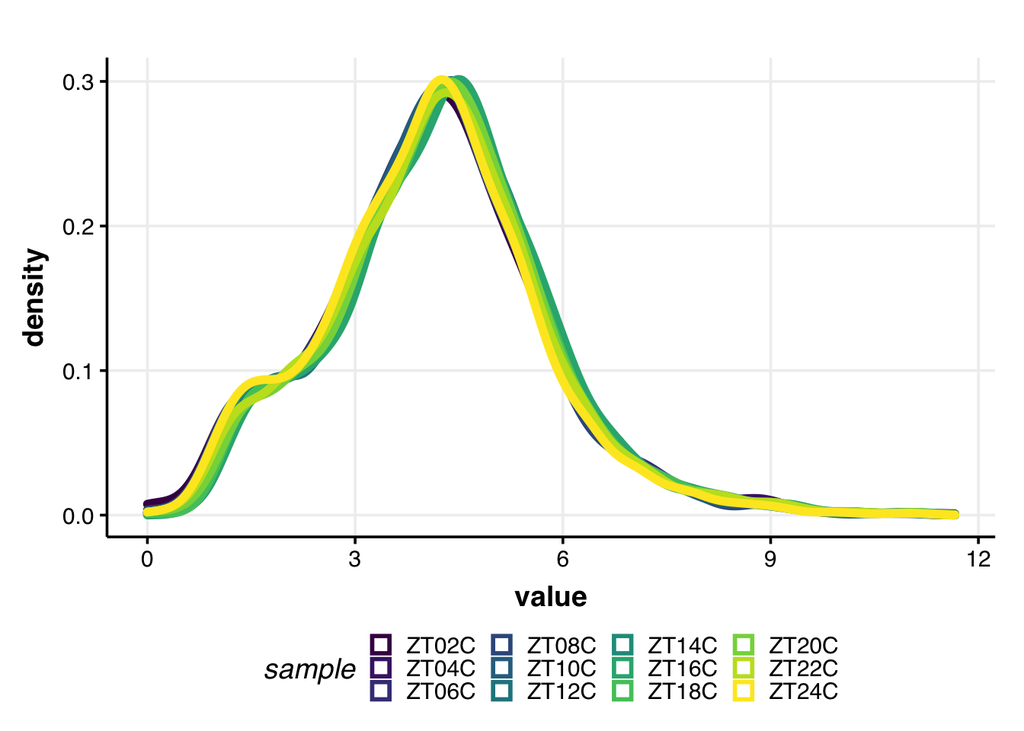

```r
ggplot(x, aes(x=value, col=sample)) + geom_density(size=2, alpha=0.8) + theme_Publication() + scale_colour_viridis_d()
```

### 1.4 Calculate gene-gene similarity

```r
# Calculate Kendall's tau-b correlation for each gene-gene pair

# sim_matrix <- cor((datExpr), method = "kendall") # this step takes time
# save(sim_matrix, file = paste0(path_to_repo, "/results/temp_files/sim_matrix_", sample.name[1], "_part2_",
#                                "_TC7.RData")) # might be useful to save the sim_matrix and
load(paste0(path_to_repo, "/results/temp_files/sim_matrix_", sample.name[1], "_part2_", "_TC7.RData")) # load it up

## Let's display a chunk of the matrix (code from Hughitt 2016; github)
heatmap_indices <- sample(nrow(sim_matrix), 200)

writeLines(paste0("Plotting a chunk of the gene-gene similarity matrix with ", length(heatmap_indices), " genes."))
```

```
## Plotting a chunk of the gene-gene similarity matrix with 200 genes.
```

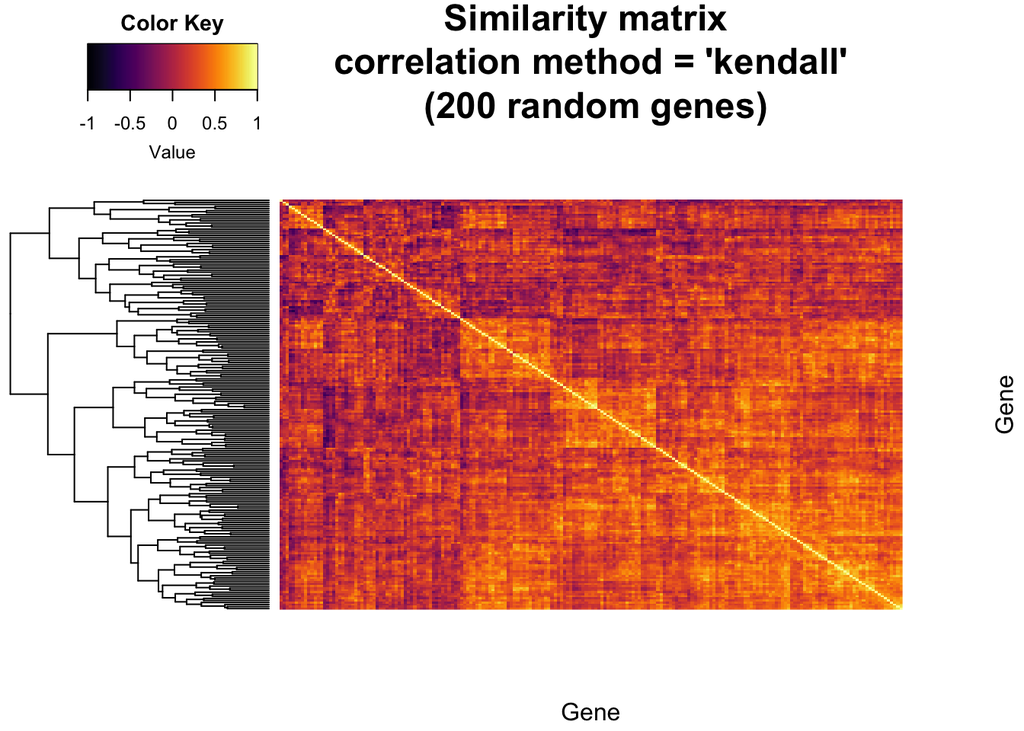

```r
gplots::heatmap.2(t(sim_matrix[heatmap_indices, heatmap_indices]),
          col=inferno(100),
          labRow=NA, labCol=NA,
          trace='none', dendrogram='row',
          xlab='Gene', ylab='Gene',
          main= paste0("Similarity matrix \n correlation method = 'kendall' \n (", length(heatmap_indices), " random genes)"),
          density.info='none', revC=TRUE)
```

### 1.5 Create adjacency matrix

- To create the adjacency matrix, we need to first identify the soft-thresholding power (see WGCNA for more info).

```r
writeLines("Performing network topology analysis to pick soft-thresholding power")
```

```
## Performing network topology analysis to pick soft-thresholding power
```

```r
# Choose a set of soft-thresholding powers
powers = c(c(1:10), seq(from = 12, to=30, by=2))
# # Call the network topology analysis function
sft = pickSoftThreshold(datExpr, powerVector = powers, verbose = 5)
```

```
## pickSoftThreshold: will use block size 3173.
##  pickSoftThreshold: calculating connectivity for given powers...
##    ..working on genes 1 through 3173 of 3173
##    Power SFT.R.sq   slope truncated.R.sq  mean.k. median.k.  max.k.
## 1      1  0.00121 -0.0894          0.903 1080.000  1080.000 1630.00
## 2      2  0.19500 -0.8260          0.874  512.000   503.000  990.00
## 3      3  0.38300 -1.0900          0.895  283.000   270.000  659.00
## 4      4  0.48400 -1.2700          0.903  172.000   159.000  464.00
## 5      5  0.54500 -1.4500          0.900  111.000    99.600  340.00
## 6      6  0.60900 -1.5000          0.926   75.400    64.900  256.00
## 7      7  0.65100 -1.6000          0.938   53.100    43.800  198.00
## 8      8  0.68600 -1.6400          0.950   38.500    30.600  156.00
## 9      9  0.70200 -1.6900          0.955   28.600    21.700  125.00
## 10    10  0.72700 -1.7200          0.962   21.700    16.000  101.00
## 11    12  0.75600 -1.7800          0.964   13.200     9.020   69.30
## 12    14  0.76700 -1.8400          0.959    8.440     5.430   49.10
## 13    16  0.79800 -1.8200          0.974    5.640     3.410   35.80
## 14    18  0.81800 -1.8200          0.982    3.910     2.220   26.80
## 15    20  0.83400 -1.8100          0.985    2.790     1.500   20.40
## 16    22  0.84500 -1.8100          0.986    2.040     1.050   15.80
## 17    24  0.85500 -1.8000          0.988    1.520     0.747   12.40
## 18    26  0.86500 -1.7900          0.991    1.150     0.548    9.95
## 19    28  0.87400 -1.8000          0.991    0.891     0.408    8.10
## 20    30  0.88000 -1.8000          0.992    0.697     0.309    6.67
```

```r
writeLines("Plotting the resutls from the network topology analysis")
```

```
## Plotting the resutls from the network topology analysis
```

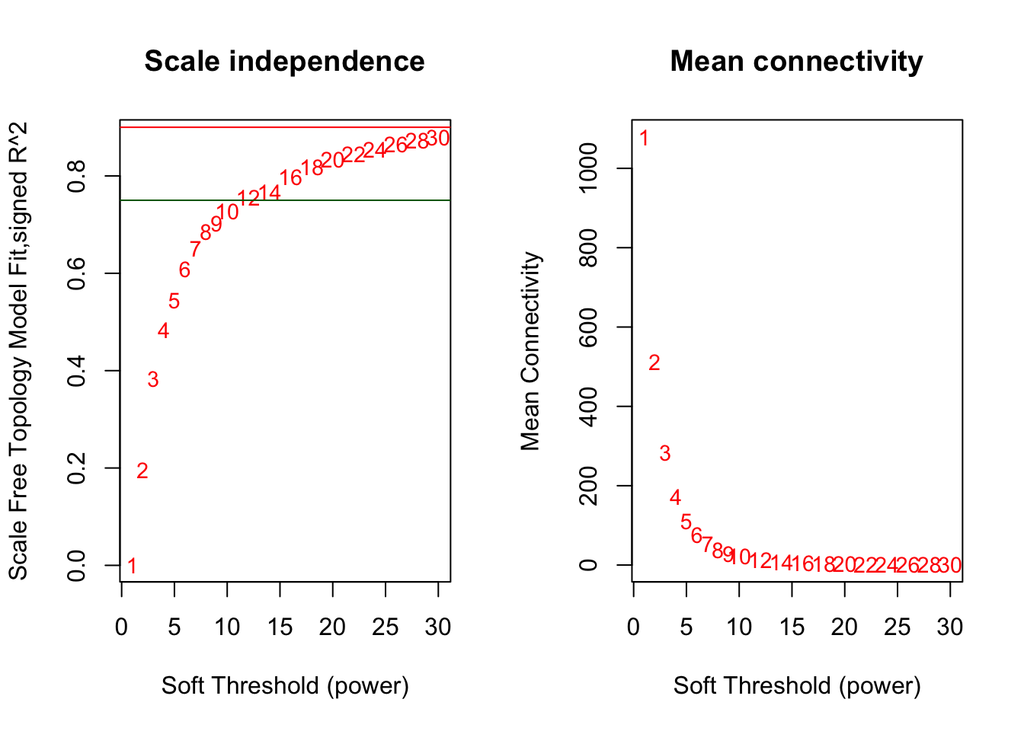

```r
# Plot the results:
# sizeGrWindow(9, 5)
par(mfrow = c(1,2));
cex1 = 0.9;
# Scale-free topology fit index as a function of the soft-thresholding power
plot(sft$fitIndices[,1], -sign(sft$fitIndices[,3])*sft$fitIndices[,2],
     xlab="Soft Threshold (power)",ylab="Scale Free Topology Model Fit,signed R^2",type="n",
     main = paste("Scale independence"));
text(sft$fitIndices[,1], -sign(sft$fitIndices[,3])*sft$fitIndices[,2],
     labels=powers,cex=cex1,col="red");
# this line corresponds to using an R^2 cut-off of h
abline(h=0.90,col="red")
abline(h=0.75,col="darkgreen")
# Mean connectivity as a function of the soft-thresholding power
plot(sft$fitIndices[,1], sft$fitIndices[,5],
     xlab="Soft Threshold (power)",ylab="Mean Connectivity", type="n",
     main = paste("Mean connectivity"))
text(sft$fitIndices[,1], sft$fitIndices[,5], labels=powers, cex=cex1,col="red")
```

> NOTE: The scale-free topology fit index reaches ~0.75 at a soft-thresholding-power=12, and it does not improve drastically beyond that.

Now, we can go ahead and create our adjacency matrix by power-transforming the similarity matrix (see WGCNA for more info).

```r
## Specify the soft-thresholding-power
soft.power = 12

# # # Construct adjacency matrix
# adj_matrix <- adjacency.fromSimilarity(sim_matrix,
#                                        power=soft.power,
#                                        type='signed')
# save(adj_matrix, file = paste0(path_to_repo, "/results/temp_files/adj_matrix_", sample.name[1], "_part2_",
#                                "_TC7.RData")) # might be useful to save the sim_matrix and
load(paste0(path_to_repo, "/results/temp_files/adj_matrix_", sample.name[1], "_part2_", "_TC7.RData")) # load it up


# Convert adj_matrix to matrix
gene_ids <- rownames(adj_matrix)

adj_matrix <- matrix(adj_matrix, nrow=nrow(adj_matrix))
rownames(adj_matrix) <- gene_ids
colnames(adj_matrix) <- gene_ids

writeLines(paste0("Plotting the power-transformed adjacency matrix for the same ", length(heatmap_indices)," genes as above"))
```

```
## Plotting the power-transformed adjacency matrix for the same 200 genes as above
```

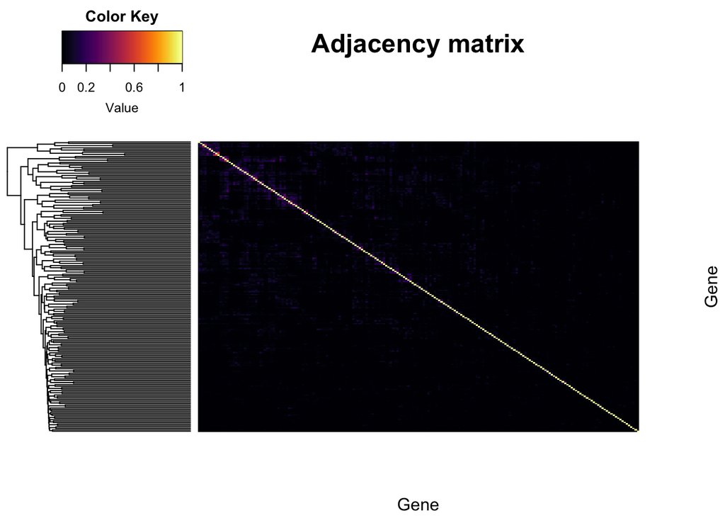

```r
## Same heatmap as before, but now with the power-transformed adjacency matrix
gplots::heatmap.2(t(adj_matrix[heatmap_indices, heatmap_indices]),
                  col=inferno(100),
                  labRow=NA, labCol=NA,
                  trace='none', dendrogram='row',
                  xlab='Gene', ylab='Gene',
                  main='Adjacency matrix',
                  density.info='none', revC=TRUE)
```

```r
## Delete similarity matrix to free up memory
rm(sim_matrix)
# gc()
```

## Step 2: Identify gene clusters

The following steps are performed as per guidelines from the WGCNA package and several tutorials made available online.

### 2.1 Create topological overalp matrix

```r
# # Turn adjacency into topological overlap
# TOM = TOMsimilarity(adj_matrix);
# dissTOM = 1-TOM
# save(dissTOM, file = paste0(path_to_repo, "/results/temp_files/dissTOM_", sample.name[1], "_part2_",
#                             "_TC7.RData")) # might be useful to save the sim_matrix and
load(paste0(path_to_repo, "/results/temp_files/dissTOM_", sample.name[1], "_part2_", "_TC7.RData")) # load it up

# Call the hierarchical clustering function
geneTree = hclust(as.dist(dissTOM), method = "average")

writeLines("Plotting the resulting clustering tree (dendrogram)")
```

```
## Plotting the resulting clustering tree (dendrogram)
```

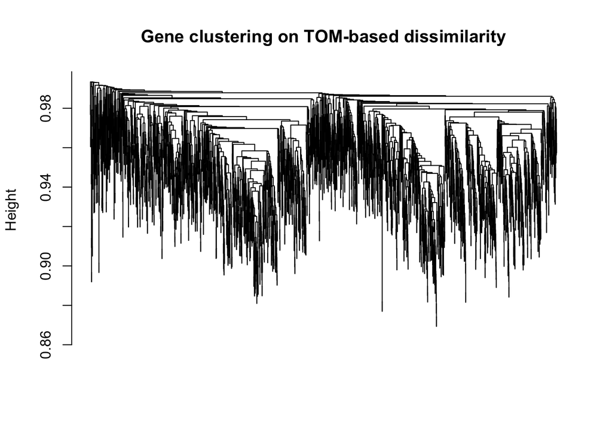

```r
# sizeGrWindow(12,9)
# reset plotting parameter
par(mfrow = c(1,1))
plot(geneTree, xlab="", sub="", main = "Gene clustering on TOM-based dissimilarity",
     labels = FALSE, hang = 0.04)
```

### 2.2 Identify clusters

User defined parameters:

- minimum size (number of genes) of modules | var-name: minModuleSize

```r
# We like large modules, so we set the minimum module size relatively high:
minModuleSize = 50;

# Module identification using dynamic tree cut:
dynamicMods= cutreeDynamic(dendro = geneTree,
                           distM = dissTOM,
                           method = "hybrid",
                           verbose = 4,
                           deepSplit = 3, # see WGCNA for more info on tuning parameters
                           pamRespectsDendro = FALSE,
                           minClusterSize = minModuleSize);
```

```
##  ..cutHeight not given, setting it to 0.993  ===>  99% of the (truncated) height range in dendro.
##  ..Going through the merge tree
##
##  ..Going through detected branches and marking clusters..
##  ..Assigning Tree Cut stage labels..
##  ..Assigning PAM stage labels..
##  ....assigned 1256 objects to existing clusters.
##  ..done.
```

```r
# view number of genes in each module
# table(dynamicMods)

writeLines("How many genes are there in each of the initial modules (clusters) detected?
Note: The names of the modules (colors) have no meaning.")
```

```
## How many genes are there in each of the initial modules (clusters) detected?
## Note: The names of the modules (colors) have no meaning.
```

```r
# Convert numeric lables into colors
dynamicColors = labels2colors(dynamicMods)
table(dynamicColors)
```

```
## dynamicColors
##        black         blue        brown         cyan        green  greenyellow
##          199          321          300          105          232          125
##         grey       grey60    lightcyan   lightgreen      magenta midnightblue
##            2           54           77           51          150           91
##         pink       purple          red       salmon          tan    turquoise
##          180          129          202          107          122          435
##       yellow
##          291
```

### 2.3 Merge similar modules

User defined parameters:

- minimum correlation between two modules above which they are merged into one | var-name: MEDissThres

```r
# Calculate eigengenes
MEList = moduleEigengenes(datExpr, colors = dynamicColors)
MEs = MEList$eigengenes

# Calculate dissimilarity of module eigengenes
MEDiss = 1-cor(MEs, method = "kendall");

writeLines("Clustering the module eigengenes and identifying a cutoff to merge similar modules")
```

```
## Clustering the module eigengenes and identifying a cutoff to merge similar modules
```

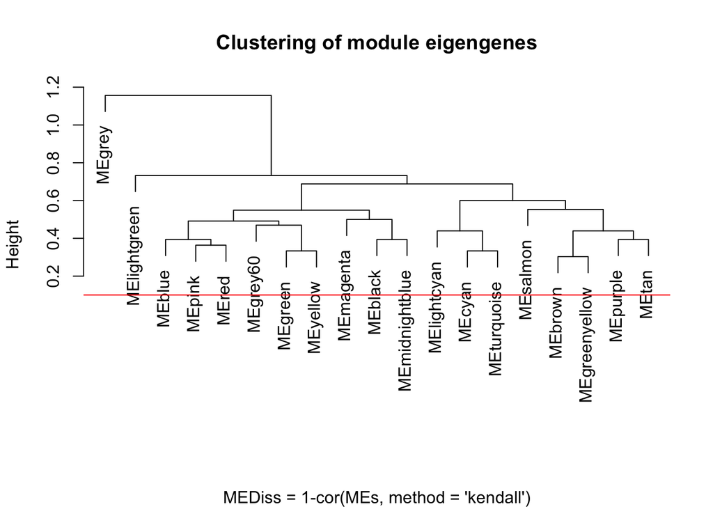

```r
# Cluster module eigengenes
METree = hclust(as.dist(MEDiss), method = "average");
# Plot the result
# sizeGrWindow(7, 8)
plot(METree, main = "Clustering of module eigengenes",
     xlab = "", sub = "MEDiss = 1-cor(MEs, method = 'kendall')")

# We choose a height cut of 0.4, corresponding to correlation of 0.6, to merge
MEDissThres = 0.1 # user-specified parameter value; see WGCNA manual for more info

# Plot the cut line into the dendrogram
abline(h=MEDissThres, col = "red")
```

```r
writeLines(paste0("Merging modules that have a correlation ≥ ", 1-MEDissThres))
```

```
## Merging modules that have a correlation ≥ 0.9
```

```r
# Call an automatic merging function
merge = mergeCloseModules(datExpr, dynamicColors, cutHeight = MEDissThres, verbose = 3)
```

```
##  mergeCloseModules: Merging modules whose distance is less than 0.1
##    multiSetMEs: Calculating module MEs.
##      Working on set 1 ...
##      moduleEigengenes: Calculating 19 module eigengenes in given set.
##    Calculating new MEs...
##    multiSetMEs: Calculating module MEs.
##      Working on set 1 ...
##      moduleEigengenes: Calculating 19 module eigengenes in given set.
```

```r
# The merged module colors
mergedColors = merge$colors;
# Eigengenes of the new merged modules:
mergedMEs = merge$newMEs;

writeLines("Plotting the identified clusters (denoted with colors) before and after merging.")
```

```
## Plotting the identified clusters (denoted with colors) before and after merging.
```

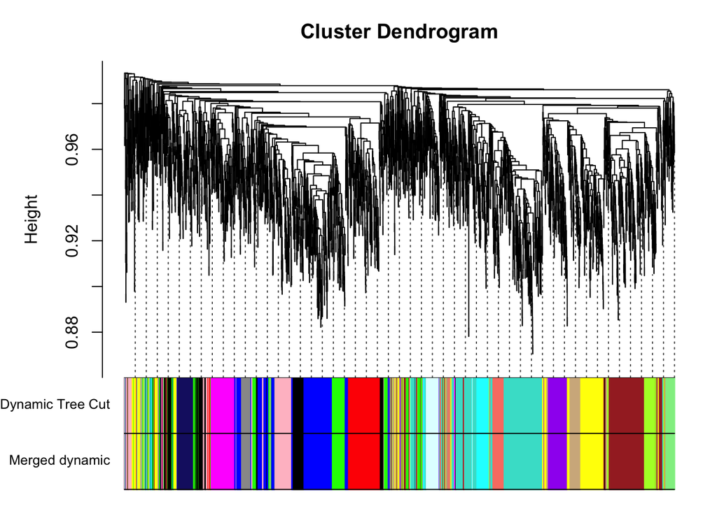

```r
# sizeGrWindow(12, 9)
plotDendroAndColors(geneTree,
                    cbind(dynamicColors, mergedColors),
                    c("Dynamic Tree Cut", "Merged dynamic"),
                    dendroLabels = FALSE, hang = 0.03,
                    addGuide = TRUE, guideHang = 0.05)
```

```r
# Rename to moduleColors
moduleColors = mergedColors

# Construct numerical labels corresponding to the colors
colorOrder = c("grey", standardColors(50));
moduleLabels = match(moduleColors, colorOrder)-1
```

### 2.4 Calculate module-module similarity

```r
writeLines("Calculating module-module similarity based on module-eigengene-expression.")
```

```
## Calculating module-module similarity based on module-eigengene-expression.
```

```r
# Calculate similarity of the eigen-genes
sim_matrix_ME <- cor(mergedMEs, method = "kendall")

# calculate adj_matrix
adj_matrix_ME <- adjacency.fromSimilarity(sim_matrix_ME,
                                          power=1, # DO NOT power transform
                                          type='signed'
)

## CHANGE THE NAMES OF THE MODULES;
module_ids <- data.frame(
  old_labels = rownames(adj_matrix_ME) %>% str_split("ME", 2) %>% sapply("[", 2) %>% as.character(),
  new_labels = paste0("S_", 1:nrow(adj_matrix_ME)))
# and coerce into matrix
adj_matrix_ME <- matrix(adj_matrix_ME, nrow=nrow(adj_matrix_ME))
rownames(adj_matrix_ME) <- module_ids$new_labels
colnames(adj_matrix_ME) <- module_ids$new_labels

# ## KEEP THE SAME MODULE NAMES (named by color)
# gene_ids <- rownames(adj_matrix_ME)
# # coerce into a matrix
# adj_matrix_ME <- matrix(adj_matrix_ME, nrow=nrow(adj_matrix_ME))
# rownames(adj_matrix_ME) <- gene_ids
# colnames(adj_matrix_ME) <- gene_ids

writeLines("Plotting the adjacency matrix that shows module-module similarity in expression")
```

```
## Plotting the adjacency matrix that shows module-module similarity in expression
```

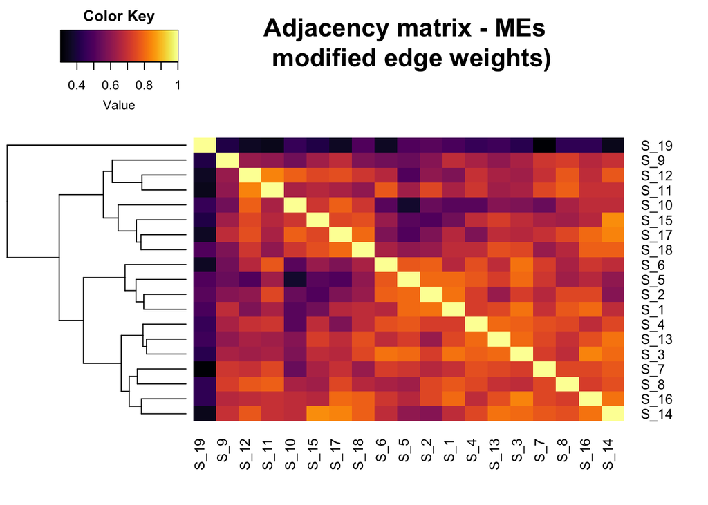

```r
gplots::heatmap.2(t(adj_matrix_ME),
                  col=inferno(100),
                  # labRow=NA, labCol=NA,
                  trace='none', dendrogram='row',
                  xlab='', ylab='',
                  # main='Similarity matrix - MEs \n correlation method = "kendall")',
                  main='Adjacency matrix - MEs \n modified edge weights)',
                  density.info='none', revC=TRUE)
```

### Calculate network stats

```r
global.network.stats <- qgraph::centrality_auto(adj_matrix_ME,
                                        weighted = TRUE, signed = F)
```

```r
pacman::p_load(igraph)

adj_matrix_ME_igraph <- adj_matrix_ME

# get rid of low correlations (0.6 & 0.8 are arbitrary) [0.7 and 0.9]
adj_matrix_ME_igraph[adj_matrix_ME_igraph < 0.8] <- 0
adj_matrix_ME_igraph[adj_matrix_ME_igraph < 0.9 & adj_matrix_ME_igraph>0] <- 0.5
adj_matrix_ME_igraph[adj_matrix_ME_igraph >= 0.9] <- 1

# build_network
network <- graph.adjacency(adj_matrix_ME_igraph,
                           mode = "upper",
                           weighted = T,
                           diag = F)

# simplify network
network <- igraph::simplify(network)  # removes self-loops

# remove isolated vertices (keep only the nodes)
isolated <- which(degree(network)==0)
network <- igraph::delete.vertices(network, isolated)

# E(network)$width <- E(network)$weight + min(E(network)$weight) + 1 # offset=1

# colors <- as.character(module_ids$old_labels)
# V(network)$color <- colors
V(network)$color <- "white"

# genes_ME <- factor(moduleColors, levels=colors) %>% summary()
V(network)$size <- igraph::degree(network, mode = "all")*3
# V(network)$size <- log2(genes_ME)^1.3

V(network)$label.color <- "black"
V(network)$frame.color <- "black"

E(network)$width <- E(network)$weight^2*4
E(network)$color <- "black"

## highlight shortest paths between two vetices
short.path <- igraph::get.shortest.paths(network, "S_5", "S_15")
E(network, path = unlist(short.path[[1]]))$color <- col.scheme[2]
E(network, path = unlist(short.path[[1]]))$width <- E(network)$weight*8

writeLines("Visualizing a simplified representation of the circadian GCN, with and without labels")
```

```
## Visualizing a simplified representation of the circadian GCN, with and without labels
```

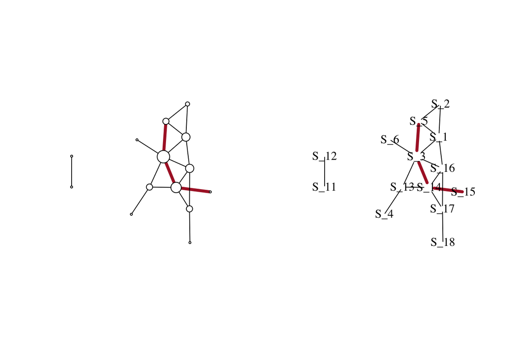

```r
par(mfrow = c(1,2))

## Circular layout
# png(paste0(path_to_repo, "/results/figures/", sample.name[1], "/", script.name,"/", sample.name[1],"_GCN_1.png"),
#     width = 20, height = 30, units = "cm", res = 1000)
# par(bg=NA)
plot(network,
     layout=layout.kamada.kawai,
       # layout=layout.fruchterman.reingold,
       # layout=layout.graphopt,
       # layout=layout_in_circle,
     vertex.label=NA
     # vertex.size=hub.score(network)$vector*30
     # vertex.shape="none"
)
# dev.off()

# png(paste0(path_to_repo, "/results/figures/", sample.name[1], "/", script.name,"/", sample.name[1],"_GCN_2.png"),
#     width = 20, height = 30, units = "cm", res = 600)
# par(bg=NA)
plot(network,
     size=20,
     layout=layout.kamada.kawai,
       # layout=layout.fruchterman.reingold
       # layout=layout.graphopt
       # layout=layout_in_circle,
     # vertex.label=NA
     # vertex.size=hub.score(network)$vector*30
     vertex.shape="none"
)
```

```r
# dev.off()
par(mfrow = c(1,1))
```

## Step 3: Annotate the network

### Module-gene list

```r
# Make a list that returns gene names for a given cluster
module_genes <- list()

# Get the genes from each of the modules
for (i in 1:length(module_ids$old_labels)) {

  # which color
  mod.color = as.character(module_ids$old_labels[[i]])

  # subset
  module_genes[[i]] <- names(datExpr)[which(moduleColors==mod.color)]
  names(module_genes)[[i]] <- as.character(module_ids$new_labels[[i]])
}
# # check the result | works
# names(module_genes)
# module_genes['C22']

# [13 Dec 2021]
# Save a csv with the module identity information for all genes used in building the GCN
# make a dataframe with gene_name and module_identity
for (i in 1:length(module_genes)){
  if (i == 1){
    cflo.control.mods <- data.frame(gene_name = module_genes[[i]],
                                    module_identity = as.character(names(module_genes)[i]))
  }
  else{
   foo <- data.frame(gene_name = module_genes[[i]],
                                    module_identity = as.character(names(module_genes)[i]))
    cflo.control.mods <- rbind(cflo.control.mods, foo)
  }

}

# # save the dataframe as a csv
# cflo.control.mods %>%
#   left_join(module_ids, by = c("module_identity" = "new_labels")) %>%
#   write.csv(.,
#             paste0(path_to_repo,
#                    "/results/WGCNA/cflo/cflo_heads_control_module_identity_new_labels.csv"),
#             row.names = F)
# # done.

# # save a copy with all the gene annotations
# # load Cflo gene annotations
# cflo_annots <- read.csv(paste0(path_to_repo,"/functions/func_data/cflo_annots.csv"),
#                             header=T, stringsAsFactors = F, na.strings = c(NA,""," "))
# cflo.control.mods %>%
#   left_join(cflo_annots, by="gene_name") %>% head()
#   write.csv(.,
#             paste0(path_to_repo,
#                    "/results/WGCNA/cflo/cflo_heads_control_module_identity_new_labels_annots.csv"),
#             row.names = F)
```

### Identify the sub-clusters

```r
## CHECK FOR OVERLAP

list1 <- module_genes

list2 <- list()
for (i in 1:length(which.modules)) {
  list2[[i]] <- mod.identity %>% filter(module_identity == which.modules[[i]]) %>% pull(gene_name)
  names(list2)[[i]] <- which.modules[[i]]
}

intersections <- list()
k <- 1
for (i in 1:length(list2)) {
  # writeLines("#########################################")
  # writeLines(paste0("Which primary module: ", names(list2)[[i]]))
  # writeLines("#########################################")
  g1 <- list2[[i]]
  for (j in 1:length(list1)) {
    # writeLines(paste0("which sub-module: ", names(list1)[[j]]))
    g2 <- list1[[j]]
    n_g1_g2 <- intersect(g1, g2)
    # save it in a list
    intersections[[k]] <- n_g1_g2
    names(intersections)[[k]] <- paste0(names(list2)[[i]], "_", names(list1)[[j]])
    k <- k+1

    # # print summary
    # writeLines(paste0("Percent of sub-module overlapping with primary module? ", round(length(n_g1_g2)/length(g2)*100,2)))
    # writeLines("----------------")
  }
}

## Make this a supplementary figure:

data.frame(sub_module = sapply(list1, length) %>% names()) %>%
  mutate(n_genes = sapply(list1, length)) %>%
  mutate(in_C21 = intersections[1:length(list1)] %>% sapply(., length)) %>%
  mutate(in_C22 = intersections[(length(list1)+1):(length(list1)*2)] %>% sapply(., length)) %>%

  pivot_longer(cols=starts_with("in"),values_to = "n_overlapping", names_to = "is_gene") %>%

  mutate(percent_overlap = n_overlapping/n_genes*100) %>%
  mutate(primary_module = ifelse(percent_overlap >= 80, str_split_fixed(is_gene,"_",2)[,2], "unassigned")) %>%
  arrange(primary_module) %>%

  filter(primary_module!="unassigned") %>%
  filter(n_genes >= 50) %>%

  select(sub_module, n_genes, percent_overlap, primary_module) %>%
  arrange(primary_module)
```

```
## # A tibble: 16 x 4
##    sub_module n_genes percent_overlap primary_module
##    <fct>        <int>           <dbl> <chr>
##  1 S_8             77            88.3 C21
##  2 S_9             51            86.3 C21
##  3 S_10           107            98.1 C21
##  4 S_11           105            99.0 C21
##  5 S_12           435            96.6 C21
##  6 S_14           300            92   C21
##  7 S_15           125            99.2 C21
##  8 S_17           129           100   C21
##  9 S_18           122            98.4 C21
## 10 S_1            180            96.7 C22
## 11 S_2            202            93.1 C22
## 12 S_3            232            83.2 C22
## 13 S_4            199            89.4 C22
## 14 S_5            321           100   C22
## 15 S_6             54            98.1 C22
## 16 S_7            150            86   C22
```

### Load genes of interest

```r
# load the list of all genes of interest
load(file = paste0(path_to_repo,"/results/genes_of_interest/goi_list.RData"))


## Rhythmic genes
rhy24.control <- goi.list[[1]][[1]][[1]]
rhy24.ocflo <- goi.list[[1]][[2]][[1]]
rhy24.beau <- goi.list[[1]][[3]][[1]]

## Ultradian genes
rhy12.control <- goi.list[[1]][[1]][[2]]
rhy12.ocflo <- goi.list[[1]][[2]][[2]]
rhy12.beau <- goi.list[[1]][[3]][[2]]
rhy08.control <- goi.list[[1]][[1]][[3]]
rhy08.ocflo <- goi.list[[1]][[2]][[3]]
rhy08.beau <- goi.list[[1]][[3]][[3]]

## DRGs
for.brain.head.rhy24.cluster1 <- goi.list[[2]]
for24.nur8 <- goi.list[[6]][[1]]

## DEGs
ocflo.up <- goi.list[[3]][[1]]
ocflo.down <- goi.list[[3]][[2]]
beau.up <- goi.list[[4]][[1]]
beau.down <- goi.list[[4]][[2]]
for.up <- goi.list[[5]][[1]]
for.down <- goi.list[[5]][[2]]

# ###-###-###-###
#   deg.dat <- readRDS(file = paste0(path_to_repo,"/results/cflo/","cflo_inf_v_control_DEGs.Rds"))
#   ophio.down <- deg.dat[[1]] %>% filter(inf_v_control == "down") %>% pull(gene_name)
#   beau.up <- deg.dat[[2]] %>% filter(inf_v_control == "up") %>% pull(gene_name)
# ###-###-###-###
# ###-###-###-###
#   deg.dat <- readRDS(file = paste0(path_to_repo,"/results/cflo/","cflo_inf_v_control_DEGs.Rds"))
#   ophio.up <- deg.dat[[1]] %>% filter(inf_v_control == "up") %>% pull(gene_name)
#   beau.down <- deg.dat[[2]] %>% filter(inf_v_control == "down") %>% pull(gene_name)
# ###-###-###-###
```

### Where are my genes at?

```r
writeLines("#####################################################
How many genes are in each of my geneset of interest?
#####################################################")
```

```
## #####################################################
## How many genes are in each of my geneset of interest?
## #####################################################
```

```r
## MAKE YOUR LIST OF GENES OF INTEREST ##

# LIST ONE - WGCNA modules
list1 <- module_genes
writeLines("List of interesting genes #1
----------------------------
Genes in each of the identified gene-clusters or modules")
```

```
## List of interesting genes #1
## ----------------------------
## Genes in each of the identified gene-clusters or modules
```

```r
sapply(list1, length)
```

```
##  S_1  S_2  S_3  S_4  S_5  S_6  S_7  S_8  S_9 S_10 S_11 S_12 S_13 S_14 S_15 S_16
##  180  202  232  199  321   54  150   77   51  107  105  435   91  300  125  291
## S_17 S_18 S_19
##  129  122    2
```

```r
## LIST TWO - rhythmic genes
list3 <- list(rhy24.control,
              # rhy24.ocflo,
              # rhy24.beau,

              # rhy12.control,
              # rhy12.ocflo,
              # rhy12.beau,

              # rhy08.control,
              # rhy08.ocflo,
              # rhy08.beau,

              for.brain.head.rhy24.cluster1,
              for24.nur8,

              # for.up,
              # for.down,
              ocflo.up,
              beau.down,
              ocflo.down,
              beau.up)
writeLines("List of interesting genes #2
----------------------------
Rhythmic genes in control Cflo heads")
```

```
## List of interesting genes #2
## ----------------------------
## Rhythmic genes in control Cflo heads
```

```r
names(list3) <- c("rhy24-controls",
                  # "rhy24-Ocflo",
                  # "rhy24-Beau",

                  # "rhy12-controls",
                  # "rhy12-Ocflo",
                  # "rhy12-Beau",
                  #
                  # "rhy08-controls",
                  # "rhy08-Ocflo",
                  # "rhy08-Beau",

                  "brain-head-rhy24-cluster1",
                  "for24-nur8",

                  # "for-UP",
                  # "for-DOWN",
                  "Ocflo-UP",
                  "Beau-DOWN",
                  "Ocflo-DOWN",
                  "Beau-UP")
sapply(list3, length)
```

```
##            rhy24-controls brain-head-rhy24-cluster1                for24-nur8
##                       852                       166                       291
##                  Ocflo-UP                 Beau-DOWN                Ocflo-DOWN
##                        81                        80                       143
##                   Beau-UP
##                       139
```

```
## Visualizing the significant overlaps between your lists of interesting genes and the identified modules
```

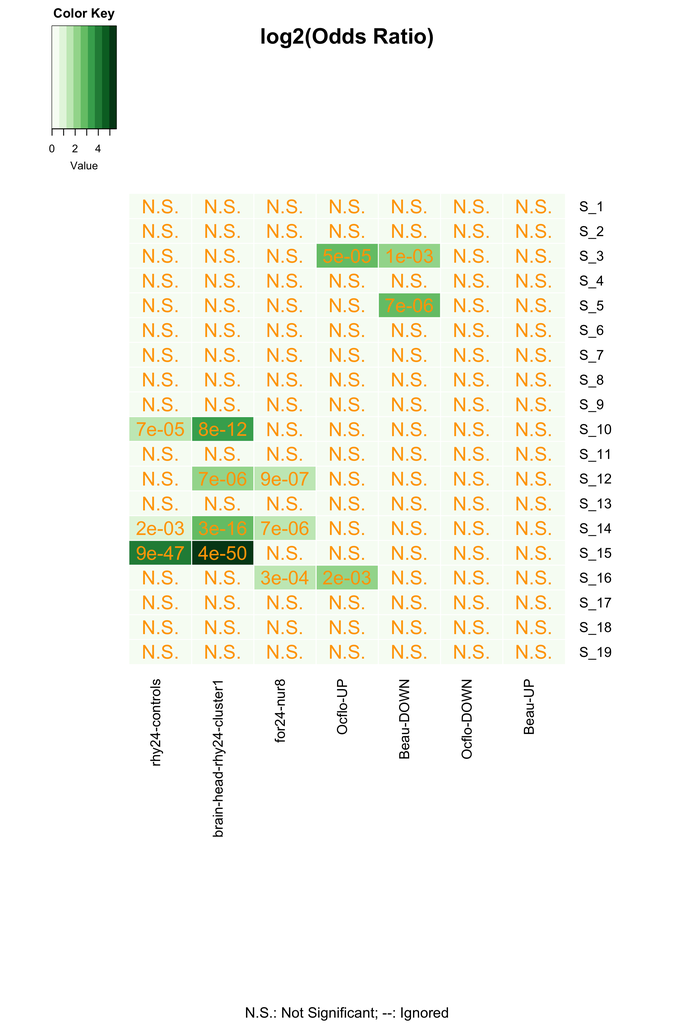

Where are my genesets of interests?

```r
## CHECK FOR OVERLAP

## make a GOM object
gom.1v3 <- newGOM(list1, list3,
       genome.size = nGenes)
png(paste0(path_to_repo, "/results/figures/", sample.name[1],"_part2_gom_1v3.png"),
    width = 20, height =30, units = "cm", res = 300)
drawHeatmap(gom.1v3,
              adj.p=T,
              cutoff=0.01,
              what="odds.ratio",
              # what="Jaccard",
              log.scale = T,
              note.col = "orange")
trash <- dev.off()

 # writeLines("How many genes exactly are overlapping between the pairwise comparisons")
# getMatrix(gom.1v4, name = "intersection") %>% t()

writeLines("Visualizing the significant overlaps between your lists of interesting genes and the identified modules")
```

Rhythmic genes

```
## [1] "Loading annotation file for Camponotus floridanus"
## [1] "Done."
## [1] "Testing for enrichment..."
```

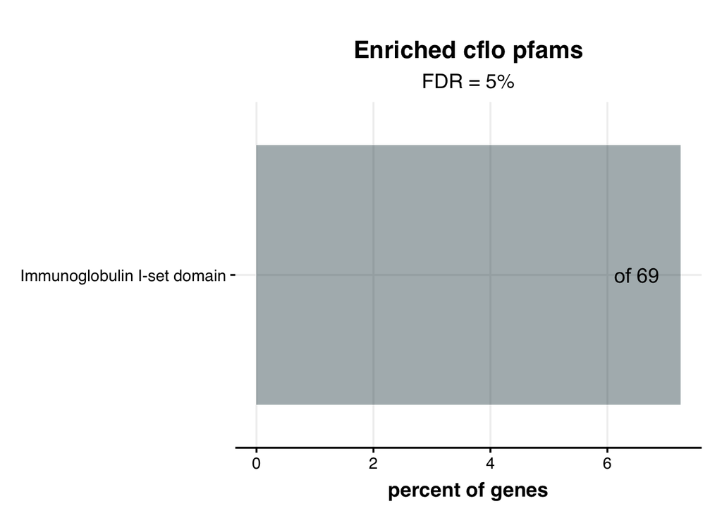

```r
module.name <- "S_3"

# all S15 genes
list1[[module.name]] %>% # n = 125 genes

  # # filter to keep only the rhythmic ones
  # intersect(., rhy24.control) %>% # n = 76

  # ## deg plot
  # deg.plot_tc7()

  # enrichment
  timecourseRnaseq::check_enrichment(.,
                                     # what = "GOs",
                                     what = "pfams",
                                     org = "cflo",
                                     bg = mod.identity.all[["gene_name"]],
                                     filter = T,
                                     plot = T,
                                     expand=T) %>% view()
```

```r
  # # zplots
  # stacked.zplot_tc7(conds="all", tc5 = F, bg.lwd = 0.5, alpha=1) %>%
  # multi.plot(rows = 3, cols=1)

  # # amplitude plots
  # amplitude.plot_tc7(cond = "all", tc5 = F, stats = T)
```

For links to circadian entrainment via hypoxic or oxidative stress in diseases, see https://www.frontiersin.org/articles/10.3389/fphys.2019.00682/full

https://www.nature.com/articles/s41467-021-25942-4

### Rhythmic genes in S14 and S15

Functions of these genes?

```
## [1] "Loading annotation file for Camponotus floridanus"
## [1] "Done."
## [1] "Testing for enrichment..."
```

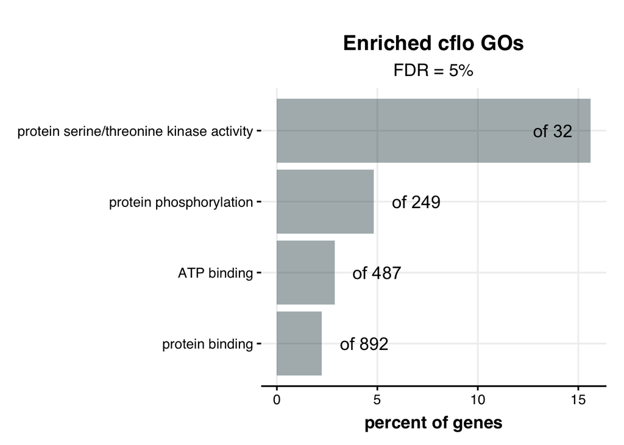

```
## # A tibble: 38 x 3
## # Groups:   gene_name [38]
##    gene_name   gene_desc                   annot_desc
##    <chr>       <chr>                       <chr>
##  1 LOC1052481… kinesin heavy chain isofor… ATP binding
##  2 LOC1052488… ankyrin-2                   protein binding
##  3 LOC1052495… caskin-1 isoform X2         protein binding
##  4 LOC1052495… cAMP-dependent protein kin… protein phosphorylation; ATP binding
##  5 LOC1052497… uncharacterized protein LO… protein binding
##  6 LOC1052497… DEAD-box ATP-dependent RNA… ATP binding
##  7 LOC1052501… retinal guanylyl cyclase 2  protein phosphorylation
##  8 LOC1052501… chromodomain-helicase-DNA-… ATP binding
##  9 LOC1052509… uncharacterized protein LO… protein binding
## 10 LOC1052511… casein kinase I isoform X2  protein serine/threonine kinase acti…
## # … with 28 more rows
```

```r
module.name <- c("S_14","S_15")
# print(module.name)
# all S15 genes
list1[[module.name[[1]]]] %>% # n = 300 genes

  # combine the 14 and 15 together
  c(list1[[module.name[[2]]]]) %>% # n = 425

  # filter to keep only the rhythmic ones
  intersect(., rhy24.control) %>% # n = 122

  # # deg plot
  # deg.plot_tc7(
  #   # ylim=c(-1,1),
  #   stats = T)

  # enrichment
  timecourseRnaseq::check_enrichment(.,
                                     what = "GOs",
                                     # what = "pfams",
                                     org = "cflo",
                                     bg = mod.identity.all[["gene_name"]],
                                     filter = T,
                                     plot = T,
                                     expand=T)
```

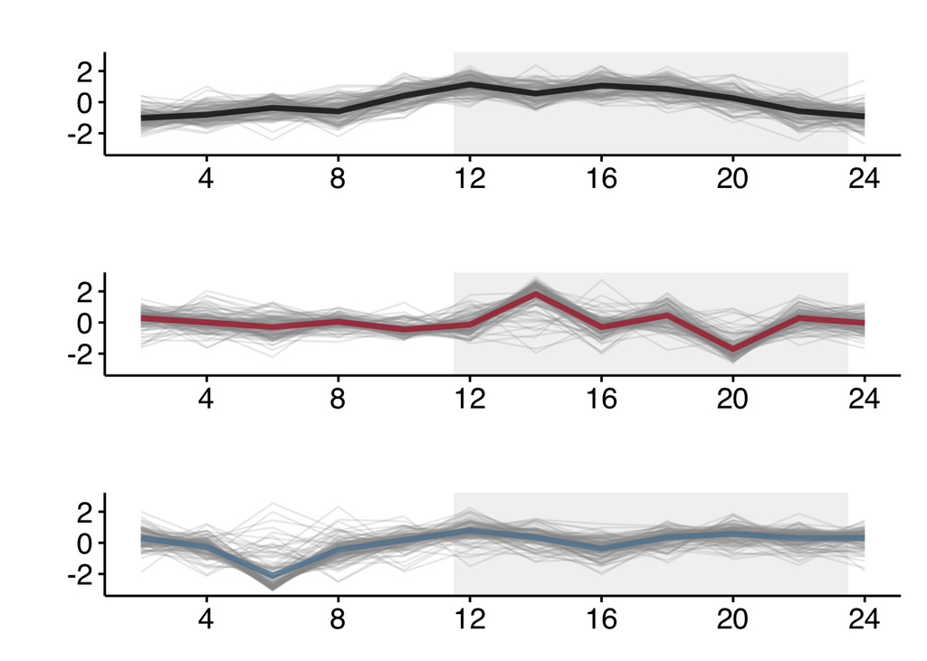

```r
list1[[module.name[[1]]]] %>% # n = 300 genes

  # combine the 14 and 15 together
  c(list1[[module.name[[2]]]]) %>% # n = 425

  # filter to keep only the rhythmic ones
  intersect(., rhy24.control) %>% # n = 122
  # zplots
  stacked.zplot_tc7(conds="all", tc5 = F, plot.mean = T, bg.alpha = 0.2) %>%
  multi.plot(rows = 3, cols=1)
```

```r
  # # amplitude plots
  # amplitude.plot_tc7(cond = "all", tc5 = T, stats = T)
```

### Sub-module: S5 (DEG)

Behavioral plasticity, task specialization

```
## [1] "Loading annotation file for Camponotus floridanus"
## [1] "Done."
## [1] "Testing for enrichment..."
```

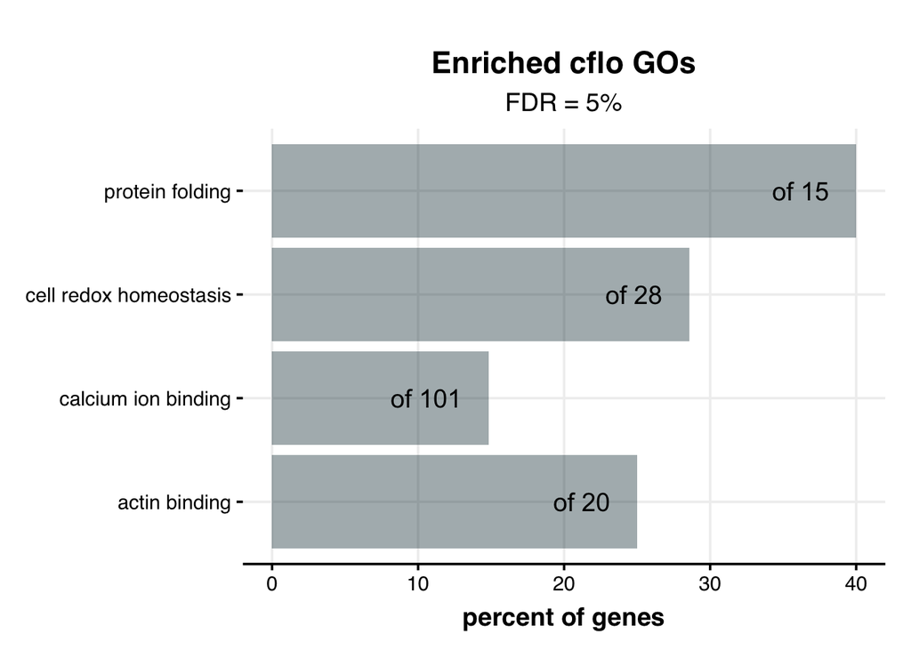

```
## # A tibble: 33 x 3
## # Groups:   gene_name [33]
##    gene_name   gene_desc                                        annot_desc
##    <chr>       <chr>                                            <chr>
##  1 LOC1052480… heat shock protein 83                            protein folding
##  2 LOC1052492… thioredoxin domain-containing protein 11 isofor… cell redox home…
##  3 LOC1052496… uncharacterized protein LOC105249601 isoform X1  calcium ion bin…
##  4 LOC1052499… protein disulfide-isomerase A3                   cell redox home…
##  5 LOC1052509… KICSTOR complex protein kaptin isoform X1        actin binding
##  6 LOC1052509… annexin B9                                       calcium ion bin…
##  7 LOC1052510… FK506-binding protein 2 isoform X2               calcium ion bin…
##  8 LOC1052510… annexin B9 isoform X2                            calcium ion bin…
##  9 LOC1052513… calpain-A isoform X3                             calcium ion bin…
## 10 LOC1052513… sushi, von Willebrand factor type A, EGF and pe… calcium ion bin…
## # … with 23 more rows
```

```r
module.name <- c("S_5","S_3")

# all s5 genes
list1[[module.name[[1]]]] %>% # n = 321 genes

  # # combine the s5 and s3 together
  c(list1[[module.name[[2]]]]) %>% # n = 553

  # # filter to keep only the rhythmic ones
  # intersect(., rhy.24[[1]]) %>% # n = 31 (s5), 40 (s5+s3)

  # # # Ocflo-UP-beau-DOWN
  # intersect(., ophio.up.beau.down) %>%
  # TC7_annotator() %>% view()

  # # deg plot
  # deg.plot_tc7(ylim=c(-1,1), stats = T)

  # enrichment
  timecourseRnaseq::check_enrichment(.,
                                     what = "GOs",
                                     # what = "pfams",
                                     # what = "TMHMM",
                                     # what = "signalP",
                                     org = "cflo",
                                     bg = mod.identity.all[["gene_name"]],
                                     filter = T,
                                     plot = T,
                                     expand=T)
```

```r
  # # zplots
  # stacked.zplot_tc7(conds="all", tc5 = T) %>%
  # multi.plot(rows = 5, cols=1)

  # # amplitude plots
  # amplitude.plot_tc7(cond = "all", tc5 = T, stats = T)
```

Thioredoxins as the potential target for host clock hijacking? https://www.ncbi.nlm.nih.gov/pmc/articles/PMC3772198/ https://journals.plos.org/ploscompbiol/article?id=10.1371/journal.pcbi.1003788 (thioredoxin reductase, beta-lactamases)

Thioredoxins in honeybees https://www.ncbi.nlm.nih.gov/pmc/articles/PMC1847502/

TMX3 https://www.pnas.org/doi/10.1073/pnas.2003667117